# Cities, a very very brief introduction

## Why should we care about cities?

The most overused figure (Nations 2009)…

> In 2009 for the first time in history 2009 more than 50% of the population lived within cities

… but still true!

Source of:

- economic growth,
- innovation - technology - …,
- but also - pandemics (!)

## Why should we care about cities?

- Strong links historically between (McCann and Acs 2011):
  - Globalisation
  - Urbanisation
  - Industrialisation

## Why should we care about cities?

[interactive chart not shown]

- Tremendous growth
- Not the same everywhere

## Urban analytics and city science

- Understand cities and how they change
- Use critically and effectively urban data
- Understand and master methodological tools
- Support urban policy making

## Different terms

- Academics love inventing new terms
- Urban science, city science, urban analytics, urban geography, geographic data science, urban data science, complexity science, TheNextBigThing
- Have a look: Batty (2019)

## Why do cities exist?

- An economist’s answer: to *economise*!
- Because of economies of scale and agglomeration economies

## Scale economies

- AKA *increasing returns to scale*, or
- AKA *economies of scale*
- Business enterprises become more efﬁcient at large scales of operation
- More output per unit of input than at smaller scales
- ➔ larger enterprises
- Within firms

## Scale economies

## Scale economies

Increasing returns to scale

- double ALL the inputs ➔
- more than double output

## Scale economies

## Scale economies

Constant returns to scale:

- double ALL the inputs ➔
- double output

## Scale economies

## Scale economies

Decreasing returns to scale

- double ALL the inputs ➔
- less than double output

## Scale economies

## Scale economies

How do they affect space?

- Clustering of workers near factories
- Clustering of services for workers near factories
- The *company town* example
- Illustrative

## Agglomeration economies

- AKA *external economies of scale*
- External to the firm
- **Very important for cities**
- Two types:
  - Localisation economies AKA Marshallian externalities
  - Urbanisation economies AKA Jacobian externalities

## Localization Economies

- Within a group of firms of the same industry
- Clustered together at the same place
- Why?
  - Information exchange
  - Labour mobility
  - Specialist services

Examples: Silicon Valley (micro-electronics), The City of London (finance), Detroit and Michigan (automobile), Seattle (aerospace), etc.

## Localization Economies

[figure not shown]

## Urbanization economies

- Firms across different sectors
- Clustered together at the same place (Jane Jacobs 1961)
- A city
- Why?
  - Support services to firms experiencing internal and localization economies
  - Clustering
  - Increased local factor prices
  - Economies of scale

## Agglomeration economies

- Diversity vs. specialization
- Internal economies of scale (firm specific)
- Localization economies (industry specific)
- Urbanization economies (city specific)

## The sources of agglomeration

1. Knowledge spillovers (Marshall 1890)
- Interactions between employees of different firms
- Proximity
- Tacit knowledge
- Mutual trading of information

## The sources of agglomeration economies

2. Non-traded local inputs
- Efficient provision of specialist inputs
- Infrastructure

## The sources of agglomeration economies

3. Local skilled labour pool
- Sufficient quantity of labour to respond to market changes
- Specialised labour / cost of training

## The sources of agglomeration economies

- Processes of learning, sharing and matching (Duranton and Puga 2004)
- Clustering:
  - Interaction
  - Dynamic
  - ➔ reduces knowledge and information transaction cost
- Higher profitability for firms within the cluster than those outside the cluster

## Agglomeration economies: pecuniary vs. technological

- Pecuniary ➔ input cost reduction
- *make inputs cheaper in larger cities*
- Technological ➔ raise productivity
- *make inputs more productive in larger cities*

Based on Brueckner (2011)

## Agglomeration economies: a citique

Bounded rationality (Simon 1955, 1966)

- Information about space and location in limited
- Relocation issues, the ability of a rational decision is limited
- Relocation cost

## Why cities do exist?

To *economise*!

In other words, collocation of people and firms increases efficiency.

## Cities as complex system

| Heterogeneity | Differences in information, profession, culture, race, ethnicity, and economic status |
| --- | --- |
| Interconnectivity | Interdependence between people, organizations, and infrastructure in networks |
| Scaling | Self-similar economies of scale per capita in material infrastructure and increasing returns to socioeconomic activity |
| Circular causality | Interdependence dynamics between socioeconomic activities, institutions, and services |
| Evolution | Open-ended change supported by new information, investment, and collective action |

Source: Bettencourt (2021)

## Cities as complex system: scale

[interactive chart not shown]

## Urban models: looking into cities

The Burgess model

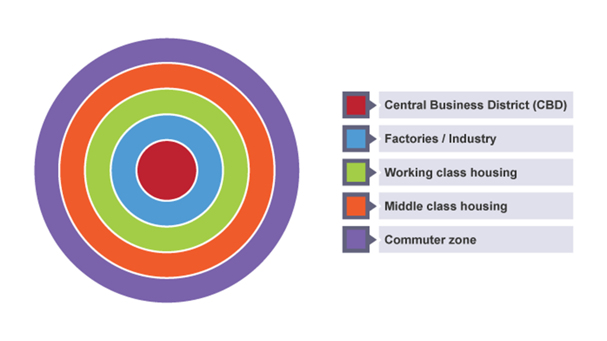

Source: [bbc.co.uk](https://www.bbc.co.uk/bitesize/guides/zckdg82/revision/1)

## Urban models: looking into cities

The Burgess model

- Created by E.W. Burgess in 1925
- Developed in rings, reflecting waves of immigrants
- Used Chicago as his model
- Most European cities developed this way (pre-automobile)

## Urban models: looking into cities

The Von Thünen model (The isolated state in 1826)

- Basic idea: Agricultural land uses follow predictable patterns around cities, which are the markets for the farm goods
- Goods with greatest demand and having the highest transport costs should be produced closest to the city

## Urban models: looking into cities

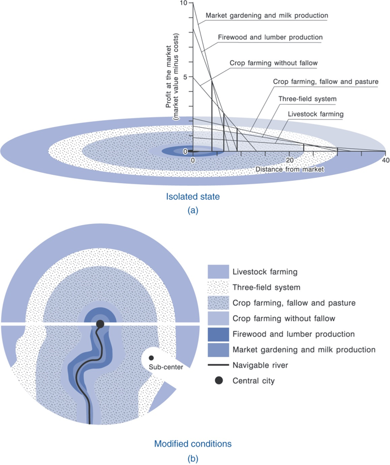

Source: Coe, Kelly, and Yeung (2019)

## Urban models: systems of cities

Why aren’t we all clustered in a huge city?

- Diseconomies of scale
- AKA Decreasing returns to scale

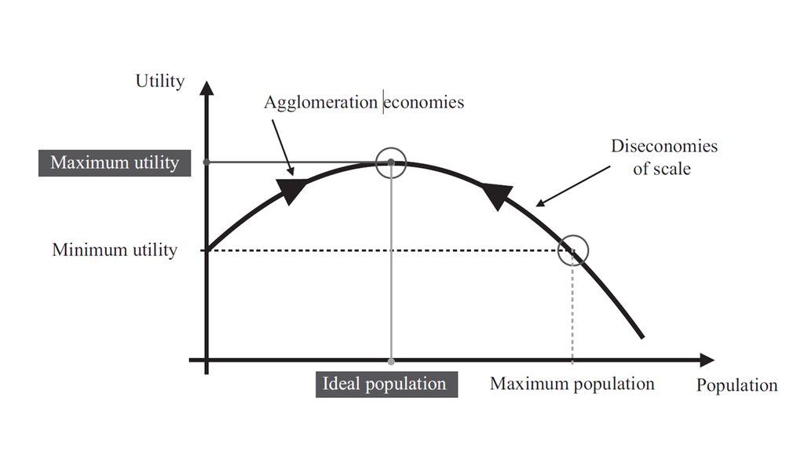

  Source: Bettencourt (2021)

## Urban models: systems of cities

Central place theory

[figure not shown]

Source: Wood and Roberts (2012) adapted from Christaller (1966)

## Urban models: systems of cities

Central place theory

## Urban models: systems of cities

The core-periphery model

- 2 region model
- Transport cost steadily fall over time
- As transport cost ⟱, separation of production and consumption becomes feasible
- ⤇ Core-periphery

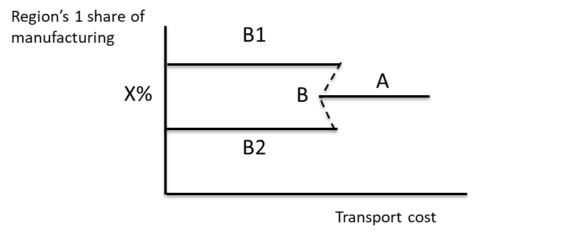

Source: Krugman and Elizondo (1996)

## Summary

- Urban structure is not random
- Multiple scales: individual, neighbourhoods, cities, urban networks
- Cities are complex adaptive systems

## References

Batty, Michael. 2019. “Urban Analytics Defined.” *Environment and Planning B: Urban Analytics and City Science* 46 (3): 403–5. https://doi.org/10.1177/2399808319839494.

Bettencourt, Luı́s MA. 2021. “Introduction to Urban Science: Evidence and Theory of Cities as Complex Systems.”

Brueckner, Jan K. 2011. *Lectures on Urban Economics*. MIT press.

Christaller, Walter. 1966. *Central Places in Southern Germany*. Vol. 10. Prentice-Hall.

Coe, Neil M, Philip F Kelly, and Henry WC Yeung. 2019. *Economic Geography: A Contemporary Introduction*. John Wiley & Sons.

Duranton, Gilles, and Diego Puga. 2004. “Micro-Foundations of Urban Agglomeration Economies.” *Handbook of Regional and Urban Economics* 4: 2063–2117.

Jane Jacobs. 1961. *The Death and Life of Great American Cities*. Vintage Books.

Krugman, Paul, and Raul Livas Elizondo. 1996. “Trade Policy and the Third World Metropolis.” *Journal of Development Economics* 49 (1): 137–50.

Marshall, Alfred. 1890. “Principles of Economics: An Introductory Volume.” The Macmillan Press Ltd.

McCann, Philip, and Zoltan J Acs. 2011. “Globalization: Countries, Cities and Multinationals.” *Regional Studies* 45 (1): 17–32.

Nations, United. 2009. *Urban and Rural Areas*. New Yorl: United Nations.

Simon, Herbert A. 1955. “A Behavioral Model of Rational Choice.” *The Quarterly Journal of Economics* 69 (1): 99–118.

———. 1966. “Theories of Decision-Making in Economics and Behavioural Science.” In *Surveys of Economic Theory*, 1–28. Springer.

Wood, Andrew, and Susan Roberts. 2012. *Economic Geography: Places, Networks and Flows*. Routledge.